# common garden tank analysis

luke reding

November 8, 2016

Before we begin…

- LL: large male only tanks
- SS: small male only tanks
- INT: intermediate male only tanks
- LS: large and small male tanks
- FF: female only tanks
- *total courtship* refers to any sort of courtship-esque event by any male. (We should have Rachel E give us a rigourous def of what she was looking for w/r/t courtship).
- *total aggression* refers to any sort of aggressive or chase event, regardless of fish identites

**to do:**

- break things apart by round / replicate

```r
library(magrittr)
library(rjson)
library(tidyverse)
library(ggthemes)
library(ggforce)
library(directlabels)
# nice colors:
palette_world <- function(n, random_order = FALSE) {
  cols <- c("#e39d25", "#d16050","#5cb3e7","#4676b1","#818b98","#4c4c4c")
  if (isTRUE(random_order))
    cols <- sample(cols)
  if (length(cols) < n)
    cols <- rep(cols, length.out = n)
  cols[1:n]
}
scale_color_world <- function(...) discrete_scale("colour", "world", palette_world, ...)
scale_fill_world <- function(...) discrete_scale("fill", "world", palette_world, ...)
# helper function: returns NA if the feild doesn't exist, otherwise returns the value
ret <- function(entry){
  if(is.null(entry)){
    return(NA)
  }
  else{
    return(entry)
  }
}
# bitchin' colors
g <- c(0.9649929502500952, 0.9531129905215493, 0.9191510752734625, 0.8593537612656912, 0.8817604211736523, 0.7700023490859729, 0.7161563289278935, 0.8232880086631527, 0.6542005475652726, 0.561817977440984, 0.7615832423359858, 0.5861204102347762, 0.43022162338501957, 0.6871358461951652, 0.5600145030589199,0.3290447800273386, 0.587268798255875, 0.5516378970902409, 0.26991762664572966, 0.46791931434441575, 0.5330773688488463, 0.24073795863422207, 0.34003177164489373, 0.4786370052053605, 0.21805042635421357, 0.22328637568306292, 0.38237877700552625, 0.17250549177124488, 0.11951843162770594, 0.24320155229883056)
greens <- c()
for(i in seq(1, length(g), by = 3)){
  greens %<>% c(rgb(g[i], g[1+i], g[2+i]))
}
greens <- colorRampPalette(greens)
di <- c("#0072B2", "#009E73", "#D55E00", "#CC79A7", "#F0E442", "#65B4E9")
diverging <- function(n){
  return(rep(di,10)[1:n])
}
theme_clean <- function(font_size = 14, font_family = "", line_size = .5) {
  half_line <- 9
  small_rel <- 0.8
  small_size <- small_rel * font_size
  theme_tufte(base_size = font_size, base_family = font_family) %+replace%
    theme(
      rect              = element_rect(fill = "transparent", colour = NA, color = NA, size = 0, linetype = 0),
      text              = element_text(family = font_family, face = "plain", colour = "black",
                                       size = font_size, hjust = 0.5, vjust = 0.5, angle = 0, lineheight = .9,
                                       margin = ggplot2::margin(), debug = FALSE),
      axis.text         = element_text(colour = "black", size = small_size),
      #axis.title        = element_text(face = "bold"),
      axis.text.x       = element_text(margin = ggplot2::margin(t = small_size / 4), vjust = 1),
      axis.text.y       = element_text(margin = ggplot2::margin(r = small_size / 4), hjust = 1),
      axis.title.x      = element_text(
        margin = ggplot2::margin(t = small_size / 2, b = small_size / 4)
      ),
      axis.title.y      = element_text(
        angle = 90,
        margin = ggplot2::margin(r = small_size / 2, l = small_size / 4),
      ),
      axis.ticks        = element_line(colour = "black", size = line_size),
      axis.line.x       = element_blank(),
      axis.line.y       = element_blank(),
      legend.key        = element_blank(),
      legend.spacing     = grid::unit(0.1, "cm"),
      legend.key.size   = grid::unit(1, "lines"),
      legend.text       = element_text(size = rel(small_rel)),
      legend.title      = element_text(size=rel(small_rel)),
      #    legend.position   = c(-0.03, 1.05),
      # legend.justification = c("left", "right"),
      panel.background  = element_blank(),
      panel.border      = element_blank(),
      panel.grid.major  = element_blank(),
      panel.grid.minor  = element_blank(),
      strip.text        = element_text(size = rel(small_rel)),
      strip.background  = element_blank(),
      plot.background   = element_blank(),
      plot.title        = element_text(hjust = 0,
                                       size = font_size*1.2,
                                       margin = ggplot2::margin(b = half_line))
    )
}
#
# theme_mod <- function(font_size = 14, font_family = "", line_size = .5) {
#   half_line <- font_size / 2
#   small_rel <- 0.8
#   small_size <- small_rel * font_size
#
#   theme_grey(base_size = font_size, base_family = font_family) %+replace%
#     theme(
#       rect              = element_rect(fill = "transparent", colour = NA, color = NA, size = 0, linetype = 0),
#       text              = element_text(family = font_family, face = "plain", colour = "black",
#                                        size = font_size, hjust = 0.5, vjust = 0.5, angle = 0, lineheight = .9,
#                                        margin = ggplot2::margin(), debug = FALSE),
#       axis.text         = element_text(colour = "black", size = small_size),
#       #axis.title        = element_text(face = "bold"),
#       axis.text.x       = element_text(margin = ggplot2::margin(t = small_size / 4), vjust = 1),
#       axis.text.y       = element_text(margin = ggplot2::margin(r = small_size / 4), hjust = 1),
#       axis.title.x      = element_text(size = font_size*0.9,
#         margin = ggplot2::margin(t = small_size / 3, b = small_size / 4)
#       ),
#       axis.title.y      = element_text(size = font_size*0.9,
#         angle = 90,
#         margin = ggplot2::margin(r = small_size / 3, l = small_size / 4),
#       ),
#       axis.ticks        = element_line(colour = "black", size = line_size),
#       axis.line         = element_line(colour = "black", size = line_size),
#       # the following two lines are not needed for ggplot2 2.2.0 or later
#       axis.line.x         = element_line(colour = "black", size = line_size),
#       axis.line.y         = element_line(colour = "black", size = line_size),
#       legend.key        = element_blank(),
#       legend.key.size   = grid::unit(1, "lines"),
#       legend.text       = element_text(size = rel(small_rel)),
#       #    legend.position   = c(-0.03, 1.05),
#       #    legend.justification = c("left", "top"),
#       panel.background  = element_blank(),
#       panel.border      = element_blank(),
#       panel.grid.major  = element_blank(),
#       panel.grid.minor  = element_blank(),
#       strip.text        = element_text(size = rel(small_rel)),
#       strip.background  = element_blank(),
#       plot.background   = element_blank(),
#       plot.title        = element_text(face = "plain",
#                                        size = font_size,
#                                        margin = ggplot2::margin(b = half_line), hjust = 0),
#
#       complete = TRUE
#     )
# }
require(ggthemes)
theme_set(theme_clean())
```

Import json files.

```r
files <- list.files("/Users/lukereding/Documents/common_garden/data/", pattern = "*.json", full.names = T)
length(files)
```

```
[1] 848
```

We have scored 848 of these short, 10-second videos.

# reading in the `json` files

Now that we’ve got the list of the file names, we’ll read them in one by one, extract various quantities, and organize everything into a data frame.

#### example json file

A single json file looks something like this:

```r
rjson::fromJSON(file=files[5])
```

```
$focal_juvenile_locations
$focal_juvenile_locations[[1]]
[1] 331 541

$focal_juvenile_locations[[2]]
[1] 720 475

$focal_juvenile_locations[[3]]
[1] 909 988

$focal_juvenile_locations[[4]]
[1] 669 968

$focal_juvenile_locations[[5]]
[1] 305 972

$focal_juvenile_locations[[6]]
[1] 364 992


$large_vs_female
[1] "0"

$number_small_male
[1] 0

$large_vs_large
[1] "0"

$pairwise_distance_females
[1] 423.7

$tank_id
[1] "INT1"

$small_courting
[1] "0"

$small_vs_female
[1] "0"
```

[output cut: 70 more lines]

```

$female_vs_female
[1] "0"

$large_vs_small
[1] "0"

$number_large_male
[1] 4

$number_model_female
[1] 3

$video_name
[1] "/Volumes/THE MOLLUSK/common_garden_weekly_videos/short_videos/03_20_2016_INT1_1min.mp4"
```

Now I get get overall courtship events (from small, intermediate, and large males) and total aggression events in the tank.

Note that I use `rowwise` here combined with `sum` inside `mutate` and (importantly) `na.rm=TRUE` to exclude NA’s (which are prsumably 0’s). This is in contrast to doing something like `mutate(total_courtship = large_courting + small_courting + intermediate_courting)` which will return `NA` if any of these variables are `NA`.

```r
# get total courtship events:
# df %<>% mutate(total_courtship = sum(large_courting + small_courting + intermediate_courting, na.rm=TRUE))
df %<>% rowwise %>% mutate(total_courtship =sum(large_courting, small_courting ,intermediate_courting, na.rm=TRUE))
# get overall (total) aggression
df %<>% rowwise %>% mutate(total_aggression = sum(large_vs_large, large_vs_small, int_vs_int, large_vs_female, int_vs_female, female_vs_female, female_vs_male, small_vs_female, na.rm= TRUE))
# get aggression towards females and aggressive towards males
df %<>%
  mutate(aggression_towards_females_by_males = sum(large_vs_female, int_vs_female, small_vs_female, na.rm= TRUE),
         aggression_towards_males_by_males = sum(large_vs_large, large_vs_small, int_vs_int, na.rm= TRUE))
df %<>% ungroup # ungroup by row
```

## look at missing data

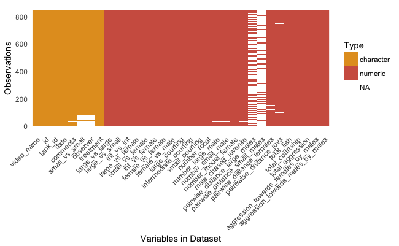

```r
library(visdat)
vis_dat(df) + scale_fill_world()
```

There are a few variables in this dataset with a lot of missing data. The main ones that stand out:

- *pairwise distance between small males*: makes sense because this only applies to LS and SS tanks
- *pairwise distance between lage males*: makes sense because this only applies to LS and LL tanks
- *observer*: I didn’t add this feild until after version 1.0 of the program
- *small vs small aggression*: same as above

Not also that there are a couple rows that have a lot of missing entries. This is probably because someone forgot to enter 0’s into the dialogue boxes.

Overall, these missing data are expected with shouldn’t be too problematic.

# wrangling

Now I define a couple functions that are useful went collapsing all the trials from a given day into a single row. This isn’t a particularly elegant wasy of doing things, but it works.

```r
# function to use to collapse all the videos from one day into a single row
avg_if_numeric <- function(x){
  if(!is.character(x)){
    return(mean(x, na.rm=T))
  }
  else{
    if(length(levels(factor(x))) > 1){
      warning("you are trying to collapse non-matching characters. will take the first one, but beware.")
    }
    return(x[1])
  }
}
sum_if_numeric <- function(x){
  if(!is.character(x)){
    return(sum(x, na.rm=T))
  }
  else{
    if(length(levels(factor(x))) > 1){
      warning("you are trying to collapse non-matching characters. will take the first one, but beware.")
    }
    return(x[1])
  }
}
```

I now create two data frame. `df_avg` contains average behaviors from one of these videos. `df` contains sums.

**Why do we need two data frames?**

For some of the videos, for whatever reason, we only have two instead of three short videos. If we want to use all the data we have, we should use `df_avg` because data from tanks where we only have two videos are comparable to tanks where we have three videos. If we want to be conservative and make sure we have a totally complete three short videos for each tank / week, we can use `df.`

```r
df$date %<>% as.Date(format = "%m-%d-%Y")
# fix typo
require(forcats)
df %<>%
  mutate(treatment = fct_recode(treatment,
    "FF"    = "LFF"
  ))
# reorder treatments
df$treatment %<>% factor(levels = c("LS", "INT", "LL", "SS", "FF"))
# to get the sum total of each behavior for each day
# exclude videos for which there are fewer than three json files
# first get the names of the videos for which there are 3 videos analyzed
good_videos = df %>%
  group_by(id) %>%
  tally %>%
  filter(n ==3) %>%
  .$id
df$good_video <- ifelse(df$id %in% good_videos, TRUE, FALSE)
# the dataframe containing the averages
df_avg <- df %>%
  group_by(id) %>%
  summarise_each(funs(if(is.numeric(.)) mean(., na.rm = TRUE) else first(.)))
df_avg$date %<>% as.Date(format = "%m-%d-%Y")
df_avg$treatment %<>% factor
# the more complete dataframe containing the sums
df %<>%
  filter(good_video == TRUE) %>%
  group_by(id) %>%
  summarise_each(funs(if(is.numeric(.)) sum(., na.rm = TRUE) else first(.)))
write_csv(df_avg, "~/Documents/common_garden/df.csv")
```

`df_avg` has 279 rows while `df` has 253, meaning that we’re missing some data for 26 videos.

Below I use `df_avg` for all the plots. Thus the yaxis is always the **average number of behaviors per 10 sec video**.

# visualizing the dataset

## define function for post-hoc labeling of groups

We can use the function define below to (1) do a permutational ANOVA, (2) do Tukey post-hoc testing, and (3) add labels to the plots showing which groups are signficantly different from other groups:

(things to add: overall anova significance)

```r
generate_label_df <- function(x, y, dataframe){
  require(lmPerm)
  require(multcompView)
  require(magrittr)
  arguments <- as.list(match.call())
  # do the anova
  model <- aovp(eval(arguments$y, dataframe) ~ eval(arguments$x, dataframe), data = dataframe)
  print(summary(model))
  if(summary(model)[[1]][5][1,] > 0.05){
    warning("the ANOVA is not significant")
  }

HSD <- TukeyHSD(model, ordered = FALSE, conf.level = 0.95)
  print(HSD)

  # Extract labels and factor levels from Tukey post-hoc
  Tukey.levels <- HSD[[1]][,4]
  Tukey.labels <- multcompLetters(Tukey.levels)['Letters']
  plot.labels <- names(Tukey.labels[['Letters']])

  boxplot.df <- split(dataframe, eval(arguments$x, dataframe)) %>%
    lapply(., function(z) eval(arguments$y, z)) %>%
    lapply(., max, na.rm=T) %>%
    unlist# %>%
    #add(((range(.)[2] - range(.)[1])))

  boxplot.df <- data.frame(
    height = boxplot.df,
    names(boxplot.df)
  )
  names(boxplot.df)[2] <- "plot.labels"
  # Create a data frame out of the factor levels and Tukey's homogenous group letters
  plot.levels <- data.frame(plot.labels,
                            labels = Tukey.labels[['Letters']],
                            stringsAsFactors = FALSE)

  # Merge it with the labels
  labels.df <- merge(plot.levels, boxplot.df, sort = FALSE)
  print(labels.df)

  return(labels.df)
}
```

Example useage:

```
[1] "Settings:  unique SS "
Component 1 :
                              Df R Sum Sq R Mean Sq Iter  Pr(Prob)
eval(arguments$x, dataframe)   4   147.19    36.797 5000 < 2.2e-16 ***
Residuals                    274   150.78     0.550
---
Signif. codes:  0 ‘***’ 0.001 ‘**’ 0.01 ‘*’ 0.05 ‘.’ 0.1 ‘ ’ 1

  Tukey multiple comparisons of means
    95% family-wise confidence level

Fit: aovp(formula = eval(arguments$y, dataframe) ~ eval(arguments$x, dataframe), data = dataframe)

$`eval(arguments$x, dataframe)`
              diff         lwr         upr     p adj
LS-LL  -0.43931973 -0.84880203 -0.02983743 0.0285808
SS-LL  -1.50000000 -1.90740896 -1.09259104 0.0000000
INT-LL -0.04897436 -0.45244691  0.35449819 0.9973268
FF-LL  -1.64000000 -2.00903984 -1.27096016 0.0000000
SS-LS  -1.06068027 -1.47016257 -0.65119797 0.0000000
INT-LS  0.39034537 -0.01522064  0.79591138 0.0655590
FF-LS  -1.20068027 -1.57200776 -0.82935279 0.0000000
INT-SS  1.45102564  1.04755309  1.85449819 0.0000000
FF-SS  -0.14000000 -0.50903984  0.22903984 0.8356961
FF-INT -1.59102564 -1.95571516 -1.22633612 0.0000000
```

| plot.labels | labels | height |
| --- | --- | --- |
| LS | a | 3.666667 |
| SS | b | 1.000000 |
| INT | ac | 4.000000 |
| FF | b | 0.000000 |
| LL | c | 4.000000 |

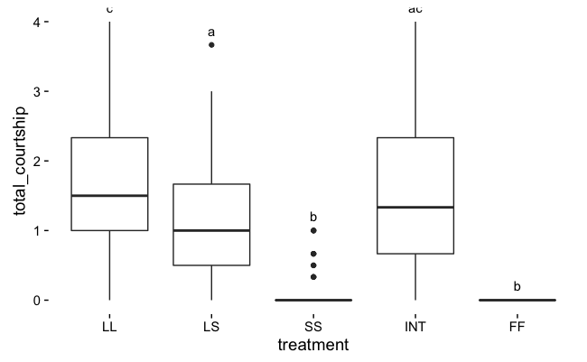

```r
ggplot(df_avg, aes(y=total_courtship, x=treatment)) +
  geom_boxplot() +
  geom_text(data = generate_label_df(x = treatment, y = total_courtship,df_avg),
            aes(x = plot.labels, y = height, label = labels), vjust = -1)
```

Groups that share a little have means that do not differ statistically.

## time trends

First we look at some time trends.

### courtship and coersion

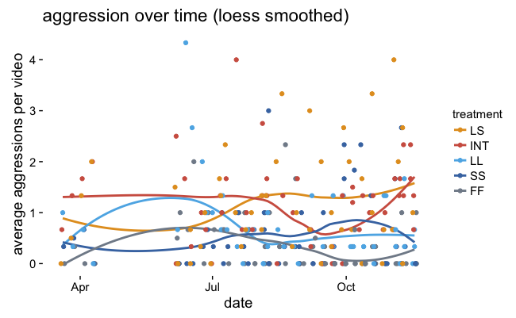

```r
require(ggthemes)
require(ggrepel)
# for adding sample sizes to plots
give.n <- function(x){
  return(c(y = median(x)*1.02, label = length(x)))
  # experiment with the multiplier to find the perfect position
}
ggplot(df_avg, aes(date, total_aggression, color = treatment)) +
  # geom_line(size=1.25, position = position_dodge(width=3)) +
  geom_smooth(se=F)+
  theme_clean() +
  geom_point(position = position_dodge(width=3)) +
  ylab("average aggressions per video") +
  # scale_color_manual(values=greens(5)[2:5]) +
  scale_color_world() +
  scale_x_date() +
  ggtitle("aggression over time (loess smoothed)")
```

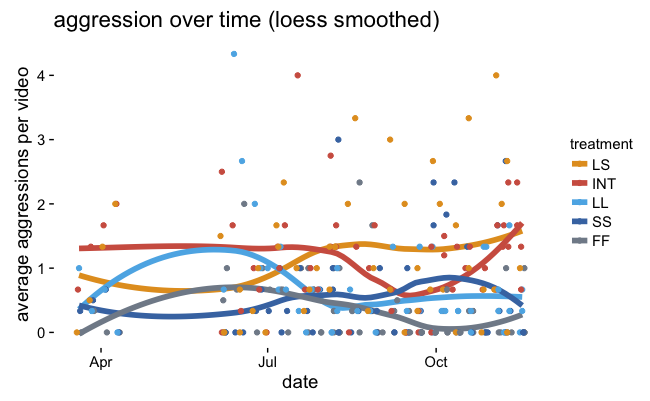

```r
ggplot(df_avg, aes(date, total_aggression, color = treatment)) +
  # geom_line(size=1.25, position = position_dodge(width=3)) +
  geom_smooth(se=F, size = 2)+
  theme_clean() +
  ylab("average aggressions per video") +
  # scale_color_manual(values=greens(5)[2:5]) +
  scale_color_world() +
  scale_x_date() +
  geom_point(position = position_dodge(width=3)) +
  ggtitle("aggression over time (loess smoothed)")
```

[figure not shown]

### distance between fish

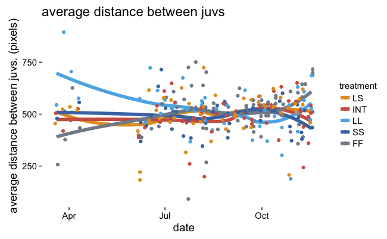

```r
ggplot(df_avg, aes(date, pairewise_distance_juvs, color = treatment)) +
  # geom_line(size=1.25, position = position_dodge(width=1)) +
  theme_clean() +
  geom_smooth(se=F, size = 2)+
  ylab("average distance between juvs. (pixels)") +
  # scale_color_manual(values=greens(5)[2:5]) +
  scale_color_world() +
  geom_point(position = position_dodge(width=3)) +
  scale_x_date() +
  ggtitle("average distance between juvs")
```

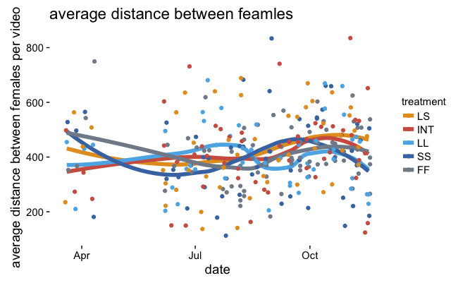

```r
ggplot(df_avg, aes(date, pairwise_distance_females, color = treatment)) +
  # geom_line(size=1.25, position = position_dodge(width=1)) +
  theme_clean() +
  geom_smooth(se=F, size = 2)+
  geom_point(position = position_dodge(width=3)) +
  ylab("average distance between females per video") +
  # scale_color_manual(values=greens(5)[2:5]) +
  scale_color_world() +
  scale_x_date() +
  ggtitle("average distance between feamles")
```

### specific aggression measures

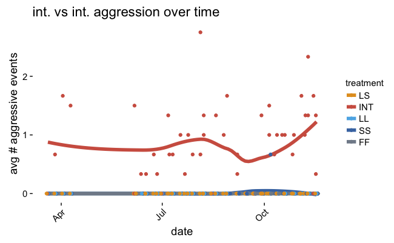

```r
ggplot(df_avg, aes(date, int_vs_int, color = treatment)) +
  # geom_line(size=1.25, position = position_dodge(width=1)) +
  theme_clean() +
  geom_smooth(se=F, size = 2)+
  geom_point(position = position_dodge(width=3)) +
  ylab("avg # aggressive events") +
  # scale_color_manual(values=greens(5)[2:5]) +
  scale_color_world() +
  theme(axis.text.x=element_text(angle=45, hjust=1)) +
  scale_x_date() +
  ggtitle("int. vs int. aggression over time")
```

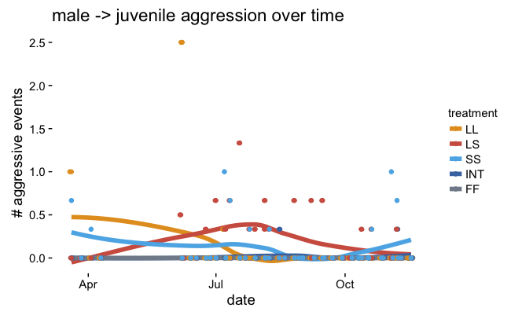

```r
ggplot(df_avg, aes(date, male_chased_juvenile, color = treatment)) +
  # geom_line(size=1.25, position = position_dodge(width=1)) +
  theme_clean() +
  geom_smooth(se=F, size = 2)+
  geom_point(position = position_dodge(width=3)) +
  ylab("# aggressive events") +
  # scale_color_manual(values=greens(5)[2:5]) +
  scale_color_world() +
  scale_x_date() +
  geom_point(aes(color = treatment))+
  ggtitle("male -> juvenile aggression over time")
```

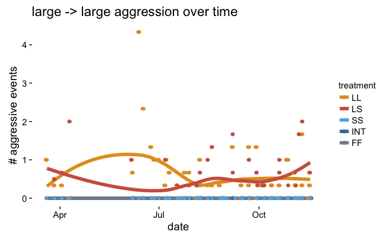

```r
ggplot(df_avg, aes(date, large_vs_large, color = treatment)) +
  # geom_line(size=1.25, position = position_dodge(width=1)) +
  theme_clean() +
  geom_smooth(se=F, size = 2)+
  geom_point(position = position_dodge(width=3)) +
  ylab("# aggressive events") +
  # scale_color_manual(values=greens(5)[2:5]) +
  scale_color_world() +
  scale_x_date() +
  geom_point(aes(color = treatment))+
  ggtitle("large -> large aggression over time")
```

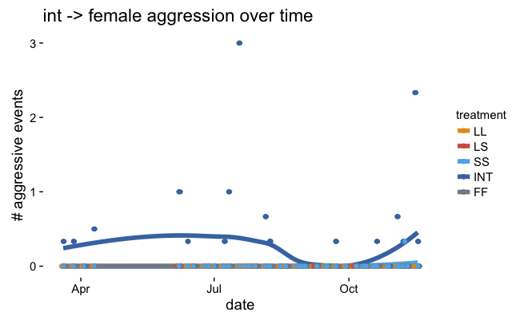

```r
ggplot(df_avg, aes(date, int_vs_female, color = treatment)) +
  # geom_line(size=1.25, position = position_dodge(width=1)) +
  theme_clean() +
  geom_smooth(se=F, size = 2)+
  geom_point(aes(color = treatment))+
  geom_point(position = position_dodge(width=3)) +
  ylab("# aggressive events") +
  # scale_color_manual(values=greens(5)[2:5]) +
  scale_color_world() +
  scale_x_date() +
  geom_point(aes(color = treatment))+
  ggtitle("int -> female aggression over time")
```

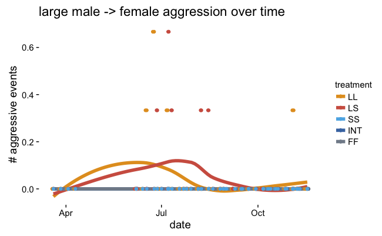

```r
ggplot(df_avg, aes(date, large_vs_female, color = treatment)) +
  # geom_line(size=1.25, position = position_dodge(width=1)) +
  theme_clean() +
  geom_smooth(se=F, size = 2)+
  geom_point(position = position_dodge(width=3)) +
  ylab("# aggressive events") +
  # scale_color_manual(values=greens(5)[2:5]) +
  scale_color_world() +
  scale_x_date() +
  geom_point(aes(color = treatment))+
  ggtitle("large male -> female aggression over time")
```

### fish counts

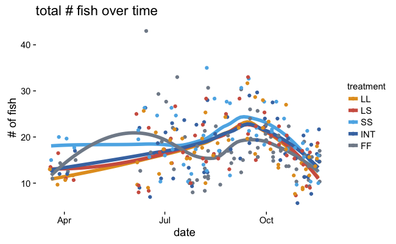

```r
ggplot(df_avg, aes(date, total_fish, color = treatment)) +
  # geom_line(size=1.25, position = position_dodge(width=1)) +
  theme_clean() +
  geom_smooth(se=F, size = 2)+
  geom_point(position = position_dodge(width=3)) +
  ylab("# of fish") +
  # scale_color_manual(values=greens(5)[2:5]) +
  scale_color_world() +
  scale_x_date() +
  ggtitle("total # fish over time")
```

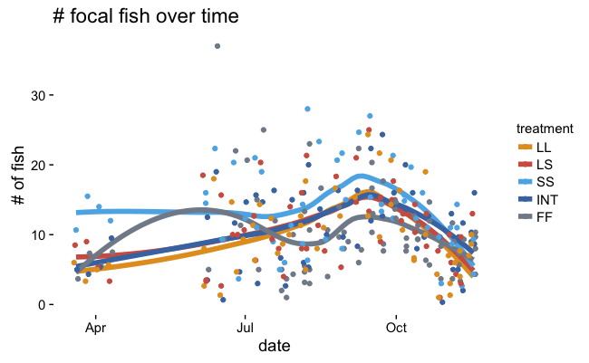

```r
ggplot(df_avg, aes(date, number_focal, color = treatment)) +
  # geom_line(size=1.25, position = position_dodge(width=1)) +
  theme_clean() +
  geom_smooth(se=F, size = 2)+
  geom_point(position = position_dodge(width=3)) +
  ylab("# of fish") +
  # scale_color_manual(values=greens(5)[2:5]) +
  scale_color_world() +
  scale_x_date() +
  ggtitle("# focal fish over time")
```

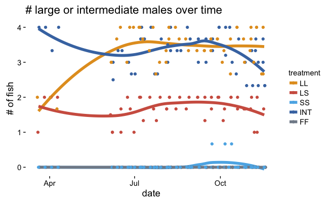

```r
ggplot(df_avg, aes(date, number_large_male, color = treatment)) +
  # geom_line(size=1.25, position = position_dodge(width=1)) +
  theme_clean() +
  geom_smooth(se=F, size = 2)+
  geom_point(position = position_dodge(width=3)) +
  ylab("# of fish") +
  # scale_color_manual(values=greens(5)[2:5]) +
  scale_color_world() +
  scale_x_date() +
  ggtitle("# large or intermediate males over time")
```

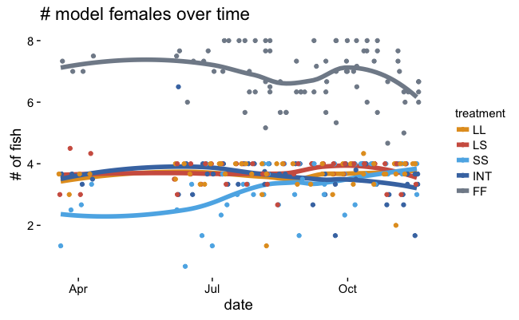

```r
ggplot(df_avg, aes(date, number_model_female, color = treatment)) +
  # geom_line(size=1.25, position = position_dodge(width=1)) +
  theme_clean() +
  geom_smooth(se=F, size = 2)+
  geom_point(position = position_dodge(width=3)) +
  ylab("# of fish") +
  # scale_color_manual(values=greens(5)[2:5]) +
  scale_color_world() +
  scale_x_date() +
  ggtitle("# model females over time")
```

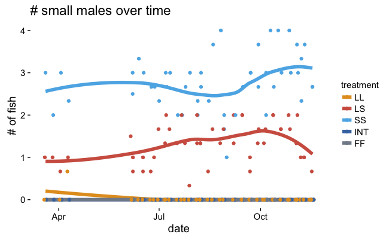

```r
ggplot(df_avg, aes(date, number_small_male, color = treatment)) +
  # geom_line(size=1.25, position = position_dodge(width=1)) +
  theme_clean() +
  geom_smooth(se=F, size = 2)+
  geom_point(position = position_dodge(width=3)) +
  ylab("# of fish") +
  # scale_color_manual(values=greens(5)[2:5]) +
  scale_color_world() +
  scale_x_date() +
  ggtitle("# small males over time")
```

## relations with courtship

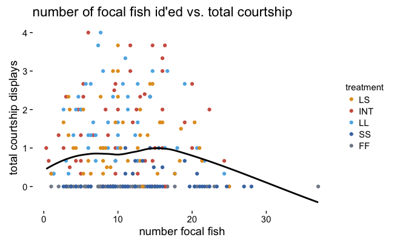

```r
df_avg %>%
  ggplot(aes(number_focal, total_courtship)) +
  geom_point(aes(color = treatment)) +
  scale_color_world() +
  geom_smooth(se = F, color = "black") +
  # scale_fill_brewer(palette = "Dark2", guide= F) +
  ylab("total courtship displays") +
  xlab("number focal fish") +
  ggtitle("number of focal fish id'ed vs. total courtship") +
  theme_clean()
```

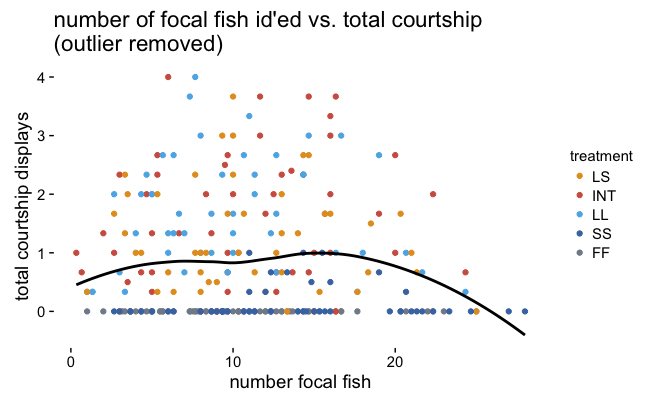

```r
# remove outlier
df_avg %>%
  filter(number_focal < 30) %>%
  ggplot(aes(number_focal, total_courtship)) +
  geom_point(aes(color = treatment)) +
  scale_color_world() +
  geom_smooth(se = F, color = "black") +
  # scale_fill_brewer(palette = "Dark2", guide= F) +
  ylab("total courtship displays") +
  xlab("number focal fish") +
  ggtitle("number of focal fish id'ed vs. total courtship\n(outlier removed)") +
  theme_clean()
```

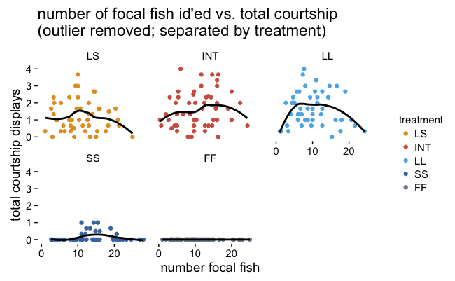

```r
df_avg %>%
  filter(number_focal < 30) %>%
  ggplot(aes(number_focal, total_courtship)) +
  geom_point(aes(color = treatment)) +
  scale_color_world() +
  geom_smooth(se = F, color = "black") +
  # scale_fill_brewer(palette = "Dark2", guide= F) +
  ylab("total courtship displays") +
  xlab("number focal fish") +
  ggtitle("number of focal fish id'ed vs. total courtship\n(outlier removed; separated by treatment)") +
  theme_clean() +
  facet_wrap(~ treatment)
```

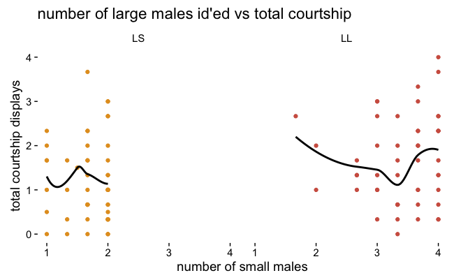

```r
df_avg %>%
  filter(treatment %in% c("LS", "LL")) %>%
  ggplot(aes(number_large_male, total_courtship)) +
  geom_point(aes(color = treatment)) +
  scale_color_world(guide = F) +
  geom_smooth(se = F, color = "black") +
  # scale_fill_brewer(palette = "Dark2", guide= F) +
  xlab("number of small males") +
  ylab("total courtship displays") +
  ggtitle("number of large males id'ed vs total courtship") +
  theme_clean() +
  facet_wrap(~ treatment)
```

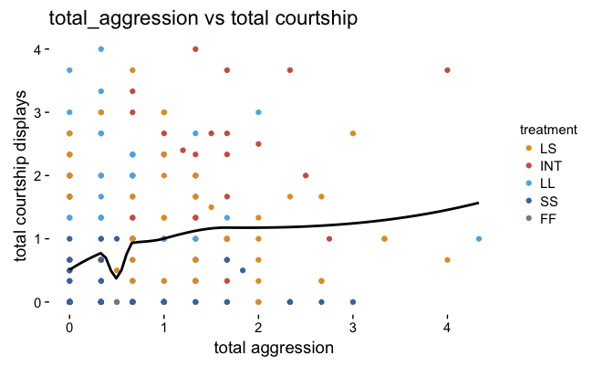

```r
df_avg %>%
  ggplot(aes(total_aggression, total_courtship)) +
  geom_point(aes(color = treatment)) +
  scale_color_world() +
  geom_smooth(se = F, color = "black") +
  # scale_fill_brewer(palette = "Dark2", guide= F) +
  ylab("total courtship displays") +
  xlab("total aggression") +
  ggtitle("total_aggression vs total courtship") +
  theme_clean()
```

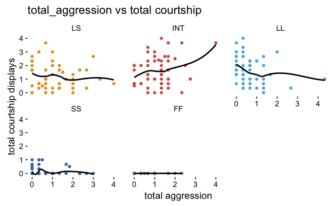

```r
df_avg %>%
  ggplot(aes(total_aggression, total_courtship)) +
  geom_point(aes(color = treatment)) +
  scale_color_world(guide=F) +
  geom_smooth(se = F, color = "black") +
  # scale_fill_brewer(palette = "Dark2", guide= F) +
  ylab("total courtship displays") +
  xlab("total aggression") +
  ggtitle("total_aggression vs total courtship") +
  theme_clean() +
  facet_wrap(~ treatment)
```

## relationships among numbers of fish identified

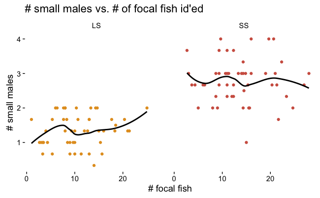

```r
df_avg %>%
  filter(treatment %in% c("LS", "SS")) %>%
  ggplot(aes(number_focal, number_small_male)) +
  geom_point(aes(color = treatment)) +
  scale_color_world(guide = F) +
  geom_smooth(se = F, color = "black") +
  # scale_fill_brewer(palette = "Dark2", guide= F) +
  ylab("# small males") +
  xlab("# focal fish") +
  ggtitle("# small males vs. # of focal fish id'ed") +
  theme_clean() +
  facet_wrap(~ treatment)
```

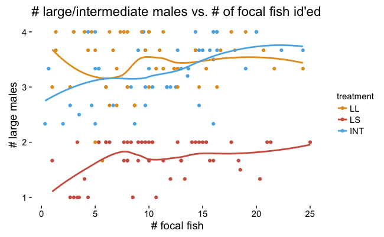

```r
df_avg %>%
  filter(treatment %in% c("LS", "LL", "INT")) %>%
  ggplot(aes(number_focal, number_large_male)) +
  geom_point(aes(color = treatment)) +
  scale_color_world() +
  geom_smooth(se = F, aes(color = treatment)) +
  # scale_fill_brewer(palette = "Dark2", guide= F) +
  ylab("# large males") +
  xlab("# focal fish") +
  ggtitle("# large/intermediate males vs. # of focal fish id'ed") +
  theme_clean()
```

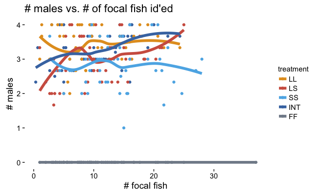

```r
df_avg %>%
  mutate(total_males = number_small_male + number_large_male) %>%
  ggplot(aes(number_focal, total_males)) +
  geom_point(aes(color = treatment)) +
  scale_color_world() +
  geom_smooth(se = F, aes(color = treatment), size = 2) +
  # scale_fill_brewer(palette = "Dark2", guide= F) +
  ylab("# males") +
  xlab("# focal fish") +
  ggtitle("# males vs. # of focal fish id'ed") +
  theme_clean()
```

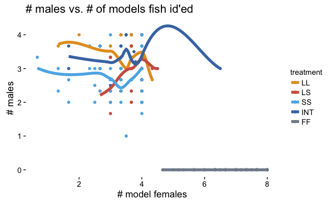

```r
df_avg %>%
  mutate(total_males = number_small_male + number_large_male) %>%
  ggplot(aes(number_model_female, total_males)) +
  geom_point(aes(color = treatment)) +
  scale_color_world() +
  geom_smooth(se = F, aes(color = treatment), size = 2) +
  # scale_fill_brewer(palette = "Dark2", guide= F) +
  ylab("# males") +
  xlab("# model females") +
  ggtitle("# males vs. # of models fish id'ed") +
  theme_clean()
```

### relationships with aggression

```r
df_avg %>%
  ggplot(aes(treatment, total_aggression)) +
  geom_boxplot(aes(fill=treatment), outlier.shape=NA, color = "black") +
  geom_sina(alpha=0.5) +
  scale_fill_world(guide = F) +
  ylab("# aggressions") +
  ggtitle("total # of aggressions per video") +
  theme_clean()+
  geom_text(data = generate_label_df(x = treatment, y = total_aggression, df_avg),
            aes(x = plot.labels, y = height, label = labels),
            size = 7, vjust = -0.2)
```

[output not shown]

```
[1] "Settings:  unique SS "
Component 1 :
                               Df R Sum Sq R Mean Sq Iter  Pr(Prob)
eval(arguments$x, dataframe)1   4   33.532    8.3831 5000 < 2.2e-16 ***
Residuals                     274  157.715    0.5756
---
Signif. codes:  0 ‘***’ 0.001 ‘**’ 0.01 ‘*’ 0.05 ‘.’ 0.1 ‘ ’ 1
```

```
Error in TukeyHSD.aov(model, ordered = FALSE, conf.level = 0.95) :
  no factors in the fitted model
```

### other differences by treatment

```
[1] "Settings:  unique SS "
Component 1 :
                              Df R Sum Sq R Mean Sq Iter  Pr(Prob)
eval(arguments$x, dataframe)   4   639.02    159.75 5000 < 2.2e-16 ***
Residuals                    274   134.23      0.49
---
Signif. codes:  0 ‘***’ 0.001 ‘**’ 0.01 ‘*’ 0.05 ‘.’ 0.1 ‘ ’ 1

  Tukey multiple comparisons of means
    95% family-wise confidence level

Fit: aovp(formula = eval(arguments$y, dataframe) ~ eval(arguments$x, dataframe), data = dataframe)

$`eval(arguments$x, dataframe)`
              diff        lwr         upr     p adj
INT-LS -0.17721743 -0.5598781  0.20544323 0.7087970
LL-LS  -0.09176871 -0.4781245  0.29458705 0.9661181
SS-LS  -0.53510204 -0.9214578 -0.14874628 0.0016407
FF-LS   3.14874411  2.7983883  3.49909995 0.0000000
LL-INT  0.08544872 -0.2952367  0.46613414 0.9724095
SS-INT -0.35788462 -0.7385700  0.02280081 0.0766103
FF-INT  3.32596154  2.9818688  3.67005430 0.0000000
SS-LL  -0.44333333 -0.8277328 -0.05893382 0.0146722
FF-LL   3.24051282  2.8923154  3.58871021 0.0000000
FF-SS   3.68384615  3.3356488  4.03204355 0.0000000
```

| plot.labels | labels | height |
| --- | --- | --- |
| INT | ab | 6.500000 |
| LL | a | 4.333333 |
| SS | b | 4.000000 |
| FF | c | 8.000000 |
| LS | a | 4.500000 |

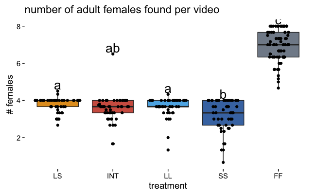

```r
require(lmPerm)
require(multcomp)
# df_avg %$%
# lmp(large_vs_large ~ treatment, data = .) %>%
#   glht(linfct=mcp(treatment="Tukey")) %>%
#   summary
df_avg %>%
  ggplot(aes(treatment, number_model_female)) +
  geom_boxplot(aes(fill=treatment), outlier.shape=NA) +
  # geom_jitter(width=0.2, size=2, height=0) +
  geom_sina() +
  scale_fill_world( guide= F) +
  ylab("# females") +
  ggtitle("number of adult females found per video") +
  theme_clean() +
  scale_size_continuous(range = c(1,6)) +
  geom_text(data = generate_label_df(x = treatment, y = number_model_female, df_avg),
            aes(x = plot.labels, y = height, label = labels),
            size = 7, vjust = -0.2)
```

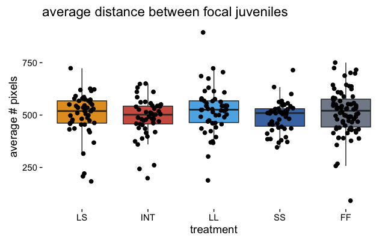

```r
# df_avg %$%
#   lmp(number_model_female ~ treatment, data = .) %>%
#   glht(linfct=mcp(treatment="Tukey")) %>%
#   summary
df_avg %>%
  ggplot(aes(treatment, pairewise_distance_juvs, fill = treatment)) +
  geom_boxplot(outlier.colour = NA) +
  geom_jitter(width=0.2, size=2, height=0) +
  theme_clean() +
  ylab("average # pixels") +
  ggtitle("average distance between focal juveniles") +
  scale_fill_world( guide= F)
```

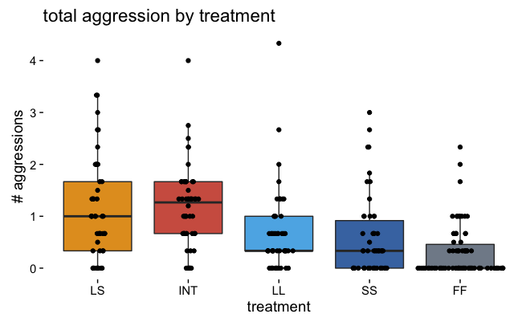

```r
df_avg %>%
  ggplot(aes(treatment, total_aggression, fill = treatment)) +
  geom_boxplot(outlier.colour = NA) +
  # geom_jitter(width=0.2, size=2, height=0) +
  geom_sina() +
  theme_clean() +
  scale_fill_world(guide = F) +
  ylab("# aggressions") +
  ggtitle("total aggression by treatment")
```

```
[1] "Settings:  unique SS "
Component 1 :
                              Df R Sum Sq R Mean Sq Iter Pr(Prob)
eval(arguments$x, dataframe)   4    21164      5291  150        1
Residuals                    274  4818336     17585
```

```
the ANOVA is not significant
```

```
  Tukey multiple comparisons of means
    95% family-wise confidence level

Fit: aovp(formula = eval(arguments$y, dataframe) ~ eval(arguments$x, dataframe), data = dataframe)

$`eval(arguments$x, dataframe)`
             diff       lwr      upr     p adj
INT-LS  -9.230923 -81.73117 63.26933 0.9967806
LL-LS  -21.835857 -95.03619 51.36448 0.9245904
SS-LS  -24.179404 -97.37974 49.02093 0.8940419
FF-LS  -19.993625 -86.37329 46.38604 0.9220759
LL-INT -12.604935 -84.73095 59.52108 0.9891350
SS-INT -14.948481 -87.07449 57.17753 0.9794210
FF-INT -10.762702 -75.95574 54.43034 0.9912477
SS-LL   -2.343547 -75.17325 70.48615 0.9999861
FF-LL    1.842233 -64.12848 67.81295 0.9999921
FF-SS    4.185779 -61.78494 70.15650 0.9997927
```

| plot.labels | labels | height |
| --- | --- | --- |
| INT | a | 835.0467 |
| LL | a | 680.9833 |
| SS | a | 833.6500 |
| FF | a | 749.5600 |
| LS | a | 688.7100 |

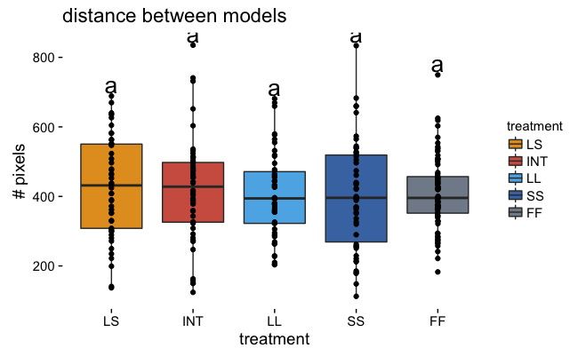

```r
df_avg %>%
  ggplot(aes(treatment, pairwise_distance_females)) +
  geom_boxplot(aes(fill=treatment), outlier.shape=NA) +
  # geom_jitter(width=0.2, size=2, height=0) +
  geom_sina() +
  scale_fill_world() +
  ylab("# pixels") +
  ggtitle("distance between models") +
  theme_clean() +
  scale_size_continuous(range = c(1,6)) +
  geom_text(data = generate_label_df(x = treatment, y = pairwise_distance_females, df_avg),
            aes(x = plot.labels, y = height, label = labels),
            size = 7, vjust = -0.2)
```